# Tree-Based & Ensemble Methods

Pouria

4/25/2022

# Libraries

```r
library(MASS)
library(tree)
library(randomForest)
library(magrittr)
library(ggplot2)
library(dplyr)
library(tidyr)
```

# Aim

We aim to gain hands-on experience with tree-based regression and ensemble methods on `Boston` data set to predict `medv` as a function of all other variables.

You may access `Boston` within the library `MASS`.

# Set seed

```r
set.seed(123)
```

# a) Split the data

Split the into training and test sets with the train-to-test ratio of 80%/20%.

```r
train.size <- nrow(data)*0.80
```

# b) Fit a regression tree and plot - Prompt

- Fit a tree onto the data and print the summary.
- Visualize the tree.
- Obtain the test MSE for the full tree.

# b) Fit a regression tree and plot

1. Fit a tree and print the summary

```
## node), split, n, deviance, yval
##       * denotes terminal node
##
##  1) root 404 34110.0 22.51
##    2) rm < 6.941 348 14110.0 20.02
##      4) lstat < 14.78 218  5458.0 23.30
##        8) dis < 1.4618 5  1061.0 38.58 *
##        9) dis > 1.4618 213  3203.0 22.94
##         18) rm < 6.542 165  1445.0 21.65 *
##         19) rm > 6.542 48   537.2 27.38 *
##      5) lstat > 14.78 130  2384.0 14.53
##       10) crim < 7.46495 74   830.7 16.89 *
##       11) crim > 7.46495 56   589.9 11.40 *
##    3) rm > 6.941 56  4462.0 37.97
##      6) rm < 7.437 34  1529.0 32.59
##       12) lstat < 8.355 29   653.8 34.07 *
##       13) lstat > 8.355 5   446.6 24.04 *
##      7) rm > 7.437 22   433.1 46.27 *
```

# b) Fit a regression tree and plot

2. Plot the tree

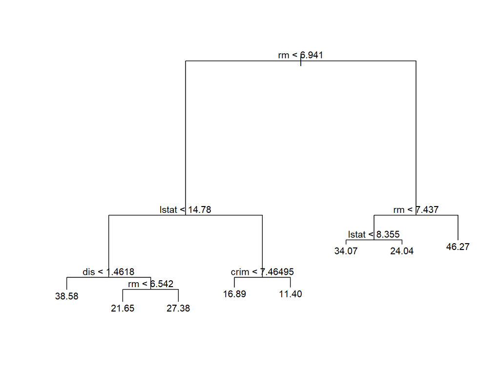

# b) Fit a regression tree and plot

2. Plot the tree; alternative way using libraries `rpart` and `rpart.plot`.

**Note**: There are a lot of other relevant libraries and functions; `ggparty`, `partykit`, `ctree()`, if you are interested.

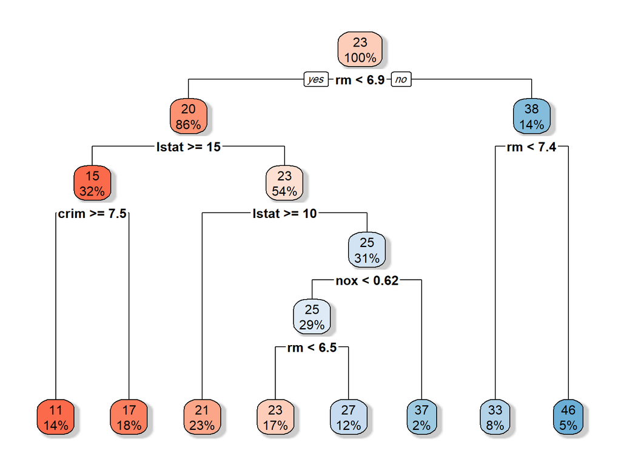

# b) Fit a regression tree and plot

3. Obtain the test MSE for this full tree.

# c) Cross-Validation - Pruning - Prompt

- Perform cross-validation on the tree.
- Plot Deviance (`dev`) as a function of tree size.
- Plot the test MSE alongside the CV MSE and training MSE across tree size.
- Prune the tree with the best parameter, and print a summary of the output, and visualize the tree.
- Output the test MSE for the best pruned tree.

# c) Cross-Validation - Pruning

# c) Cross-Validation - Pruning

2. Plot the results of the CV and show on the plot the tree size that corresponds to the best (least) CV error (`dev`).

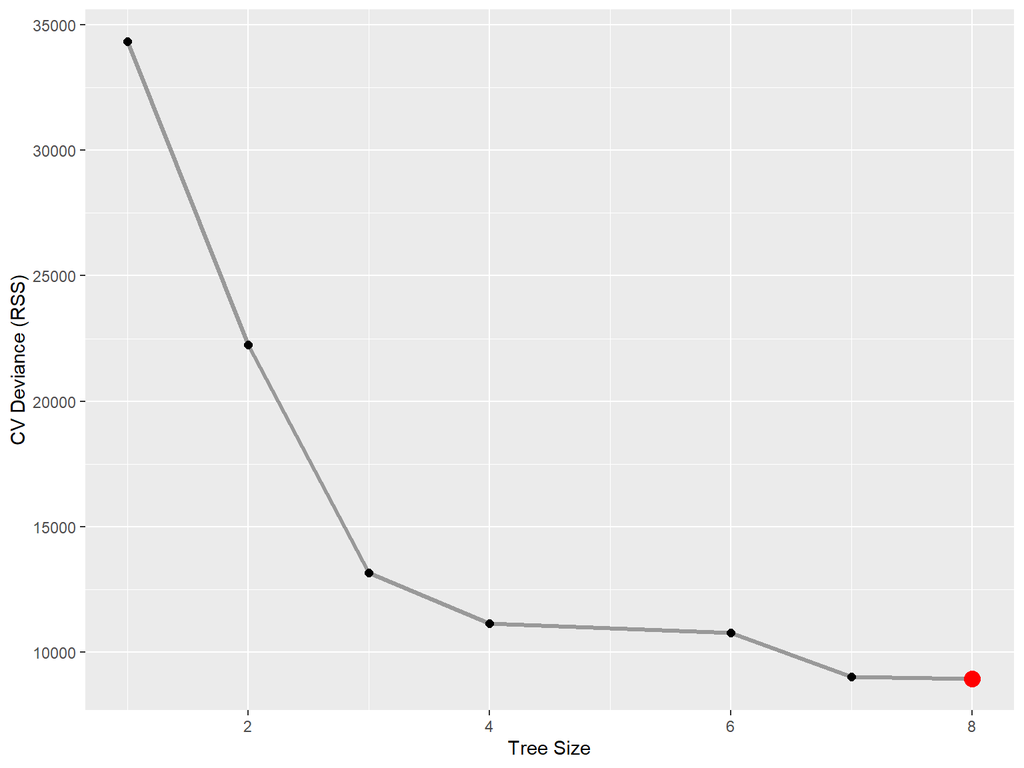

# c) Cross-Validation - Pruning

# c) Cross-Validation - Pruning

3. Plot the test MSE alongside the CV MSE and training MSE across tree size.

*Note*: For CV MSE, you may use the deviance output, but also ensure to divide it by `train.size`.

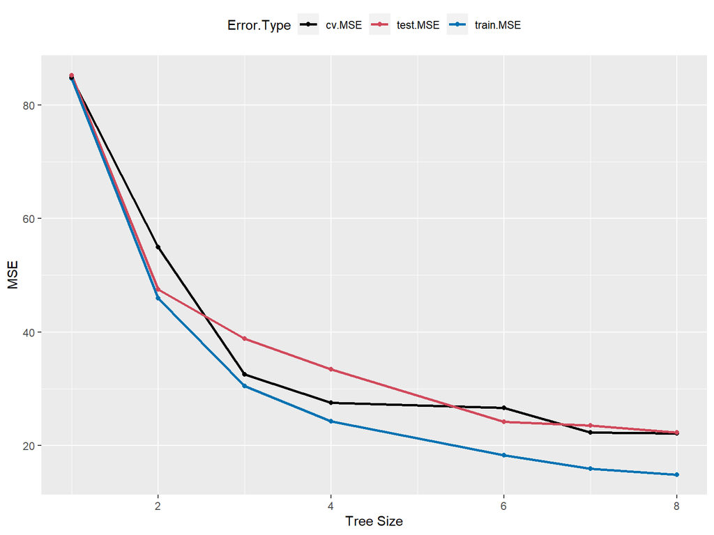

# c) Cross-Validation - Pruning

# c) Cross-Validation - Pruning

5. Visualize the pruned tree.

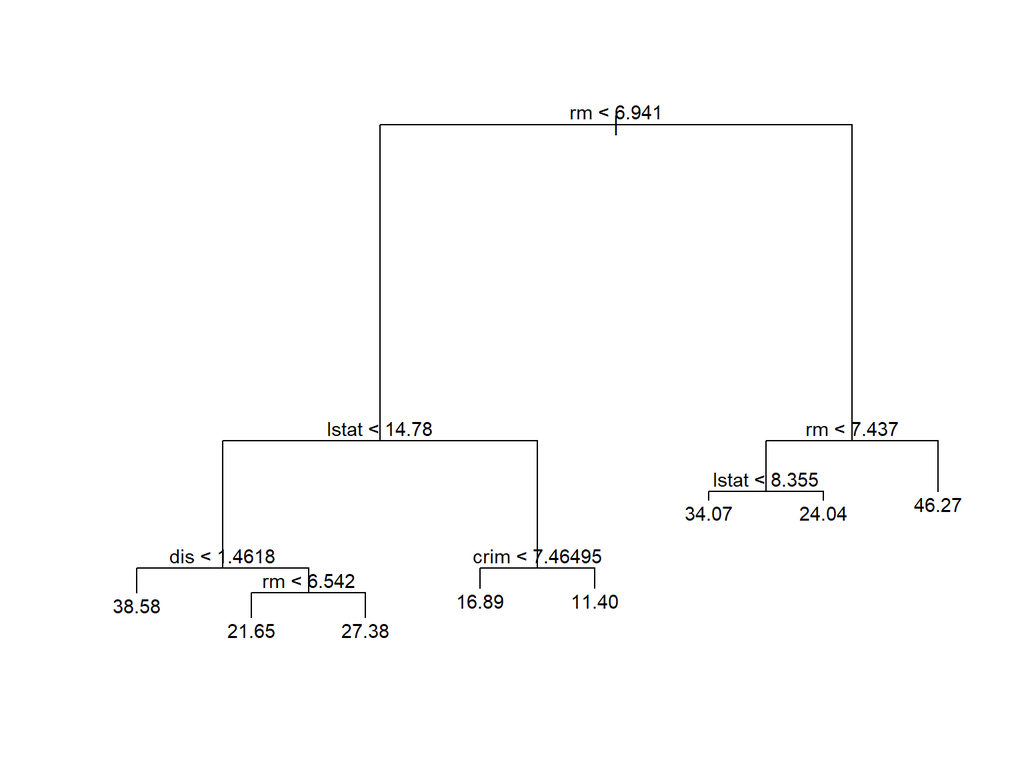

# c) Cross-Validation - Pruning

6. Obtain the test MSE for the best pruned model.

# d) Bagging - Prompt

- Use the bagging approach in order to analyze this data.
- What test MSE do you obtain?
- Use the `importance()` function to determine which variables are most important.
- Plot the importance values in a bar plot.

# d) Bagging

# d) Bagging

# d) Bagging

2. What test MSE do you obtain? Compare it with that obtained using the pruned tree in (c).

# d) Bagging

3. Use the `importance()` function to determine which variables are most important.
- `%IncMSE`, which is the average increase of model accuracy in predicting the outcome of the out-of-bag samples when a specific variable is included from the model.
- `IncNodePurity`, which is the average increase in node purity that results from splits over that variable. This is based on Gini (for classification) or RSS (for regression) on the training set. These measures, calculated using the training set, are less reliable than a measure calculated on out-of-bag data (such as `%IncMSE`).

```
##           %IncMSE IncNodePurity
## crim    13.732675    1278.49962
## zn       3.359804      27.98022
## indus    9.485221     169.04765
## chas     2.470410      31.52038
## nox     25.061637     527.52052
## rm      54.986600   14524.03877
## age      8.628663     428.50616
## dis     29.652276    2245.68569
## rad      3.201523      81.10893
## tax     10.857230     544.15705
## ptratio 22.062368     493.69728
## black    5.419177     273.52558
## lstat   37.856243   13041.42100
```

# d) Bagging

4. Plot the importance values based on the out-of-bag error `%IncMSE` on a bar plot (Normalize all to the most important variable).

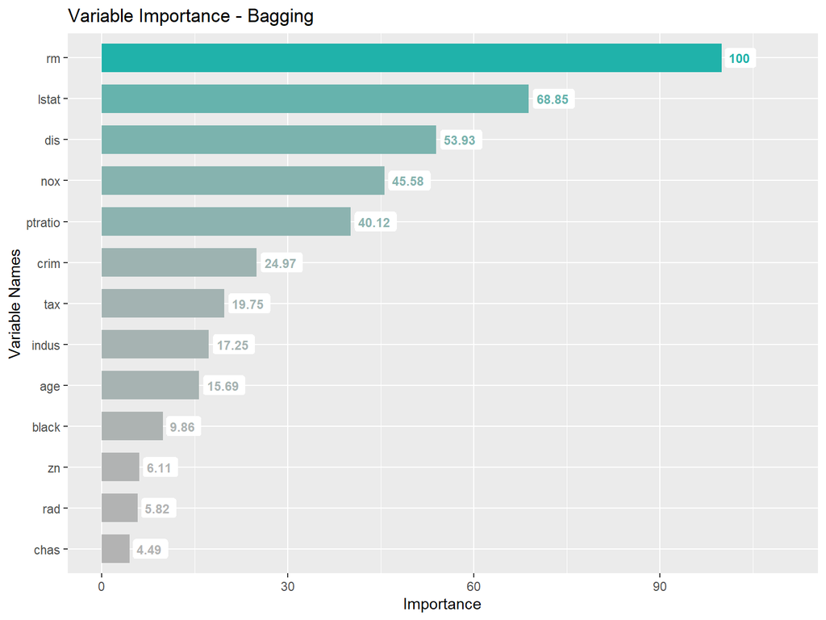

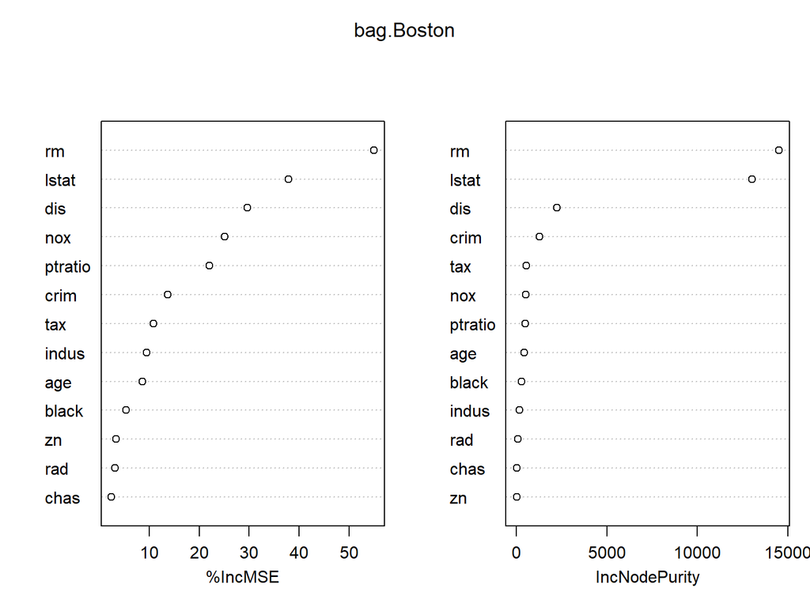

# e) Random Forest - Prompt

- Use random forests to analyze this data.
- What test MSE do you obtain?
- Use the `importance()` function to determine which variables are most important.
- Describe the effect of m, the number of variables considered at each split, on the error rate obtained.

# e) Random Forest

# e) Random Forest

# e) Random Forest

2. What **test MSE** do you obtain? Compare it with those obtained using the pruned tree in (c) and using Bagging in (d).

# e) Random Forest

3. Use the `importance()` function to determine which variables are most important.

# e) Random Forest

4. Plot the importance values in a bar plot.

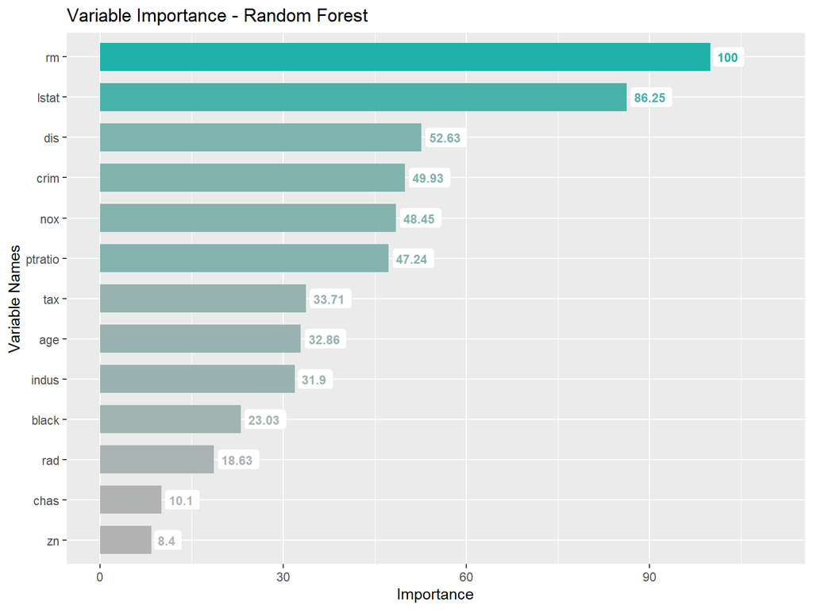

# f) Random Forest vs. Bagging - Make comments

- First, How is Random Forest different from Bagging in essence?
- Look back at both CV errors and test errors obtained using Random Forest and Bagging. How did using each of these ensemble methods change the fitting performance and predictive power of a single tree. Can you relate this to the effect of the number of variables considered at each split?